# Normaaljaotusega histogrammi funktsioon

Allar Haav

September 25, 2014

Kirjutasin viimasest praktikumist inspireerituna ühe väikese funktsiooni normaaljaotusega histogrammide kergemaks meisterdamiseks: on ehk vähem segadust ning hõlpsam toimetada. Funktsioon asub omaette failis: `histnorm.R`. Esmalt tuleb see fail asetada kuhugi mugavasse ja eeldatavalt ilma täpitähtedeta paika. Kõige parem on aga kui see asub teie avatud projekti kaustas: siis ei pea pikalt asukohta täpsustama.

Selleks, et funktsiooni kasutada, tuleb see ka eelnevalt laadida. Selleks on olemas käsk `source()`

```r
# Kui fail asub suvalises kohas, tuleb selle asupaik pikalt kirjeldada:
source("C:/R/Andmeanalyys/scripts/histnorm.R")
# Kui aga fail asub avatud projekti (alam)kaustas, siis alternatiivselt:
source("scripts/histnorm.R")
```

Funktsioon `histnorm()` on põhimõtteliselt sama, mis `hist()` ning lisaparameetreid tasub just viimase helpist vaadata-otsida. Erinevus on aga see, et lisaks joonistatakse peale vastava normaaljaotuse funktsioon joonena. Kui histogrammi värvust, telgede tekste jms saab tavapäraselt muuta, siis joonele lisasin kaks parameetrit: `linecol` ja `lineweight`, mis muudavad vastavalt joone värvi ja paksust. Vaikeväärtused on must ja 1.

Teeme mõned näited läbi. Esmalt teeme vektori 100 suvalise väärtusega normaaljaotusest, mille keskväärtus on 10 ning standardhälve 1. Seejärel teeme sellest graafiku:

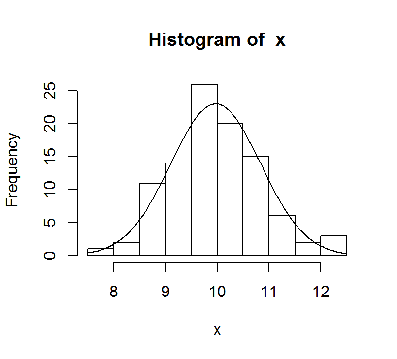

```r
x <- rnorm(100, 10, 1)
histnorm(x)
```

Kui lisame parameetri `prob = TRUE`, siis kuvatakse y-teljele hoopis tõenäosusväärtused.

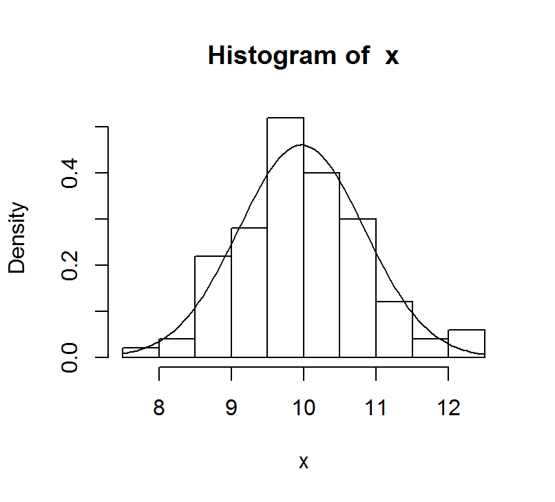

```r
histnorm(x, prob=TRUE)
```

Joone värvi ja paksust saab niisiis muuta kahe lisaparameetriga `linecol` ja `lineweight`:

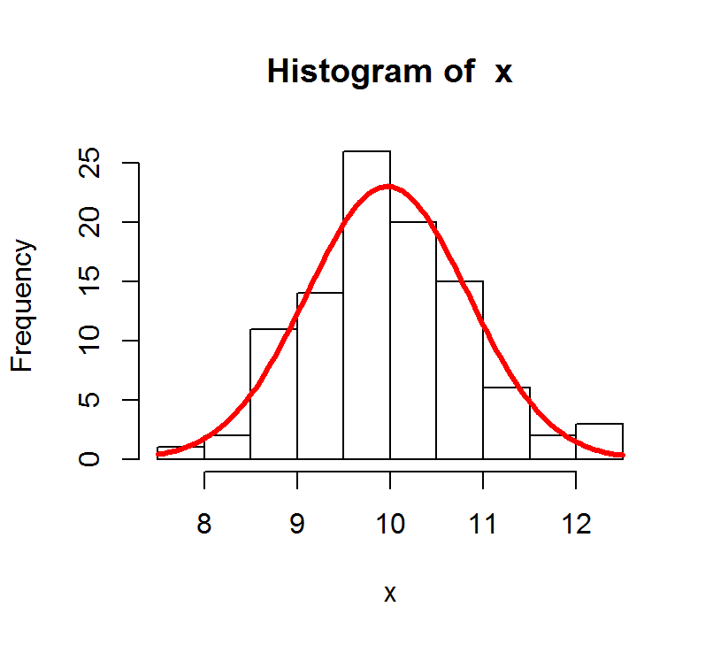

```r
histnorm(x, linecol="red", lineweight=3)
```

Ja otseloomulikult saab ka kõike muud histogrammi juures muuta. Näiteks:

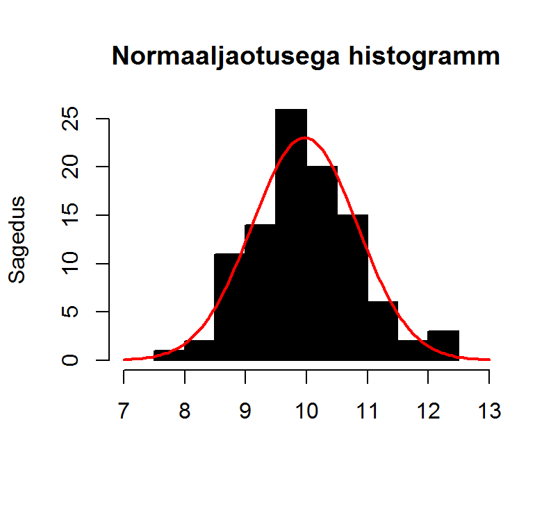

```r
histnorm(x, linecol="red", lineweight=2, main="Normaaljaotusega histogramm",
         col="black", xlim=c(7,13), ylim=c(0,25), xlab="", ylab="Sagedus")
```

Loodan, et sellest on kasu :)